# HW: Getting familiar with `ggplot2`

Kyle Dean

Load the `tidyverse` package

```r
library(tidyverse)
install.packages(qwraps2)
```

```
Error in install.packages : object 'qwraps2' not found
```

# Problem 1

You will use the `diamonds` dataset that comes with `ggplot2` (already loaded when you use `library(tidyverse`)). You can explore the dataset by using the function `str()`:

```r
str(diamonds)
```

```
tibble [53,940 x 10] (S3: tbl_df/tbl/data.frame)
 $ carat  : num [1:53940] 0.23 0.21 0.23 0.29 0.31 0.24 0.24 0.26 0.22 0.23 ...
 $ cut    : Ord.factor w/ 5 levels "Fair"<"Good"<..: 5 4 2 4 2 3 3 3 1 3 ...
 $ color  : Ord.factor w/ 7 levels "D"<"E"<"F"<"G"<..: 2 2 2 6 7 7 6 5 2 5 ...
 $ clarity: Ord.factor w/ 8 levels "I1"<"SI2"<"SI1"<..: 2 3 5 4 2 6 7 3 4 5 ...
 $ depth  : num [1:53940] 61.5 59.8 56.9 62.4 63.3 62.8 62.3 61.9 65.1 59.4 ...
 $ table  : num [1:53940] 55 61 65 58 58 57 57 55 61 61 ...
 $ price  : int [1:53940] 326 326 327 334 335 336 336 337 337 338 ...
 $ x      : num [1:53940] 3.95 3.89 4.05 4.2 4.34 3.94 3.95 4.07 3.87 4 ...
 $ y      : num [1:53940] 3.98 3.84 4.07 4.23 4.35 3.96 3.98 4.11 3.78 4.05 ...
 $ z      : num [1:53940] 2.43 2.31 2.31 2.63 2.75 2.48 2.47 2.53 2.49 2.39 ...
```

1. Create a bar-plot using `geom_bar()`, mapping the `clarity` to the `x` aesthetic, and `cut` to the `fill` aesthetic. What do you notice?

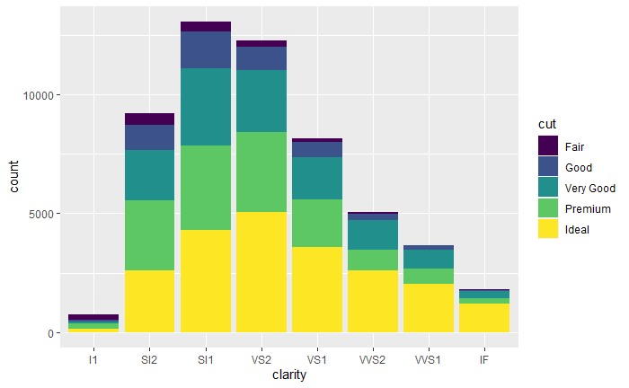

```r
ggplot(data = diamonds) +
  geom_bar(mapping = aes(x = clarity, fill = cut))
```

Here we can see the different types of clarity on the X axis and the Y axis showing the number of entries in the dataset. The bars themselves are filled with the separate number of different cuts found with each type of clarity.

2. What happens if you use the option `position = "fill"` in the plot above?

```
Ignoring unknown aesthetics: position
```

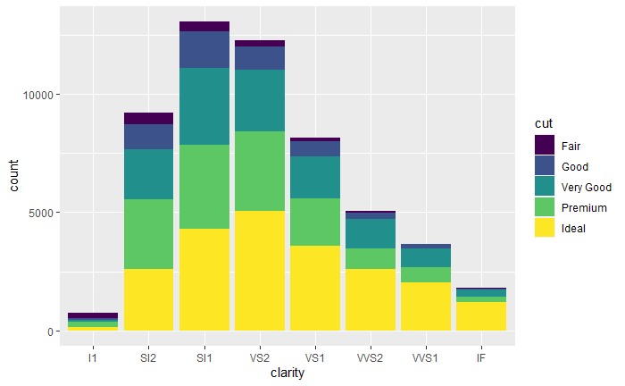

```r
ggplot(data = diamonds) +
  geom_bar(mapping = aes(x = clarity, fill = cut, position = "fill"))
```

The code executed and shows an identical graph, but the console says it ignores position.

# Problem 2

In this problem you will use the `midwest` dataset, also available with the `ggplot2` package. The data comes from the 2000 US Census. Learn more about the `midwest` dataset here

```r
str(midwest)
```

```
tibble [437 x 28] (S3: tbl_df/tbl/data.frame)
 $ PID                 : int [1:437] 561 562 563 564 565 566 567 568 569 570 ...
 $ county              : chr [1:437] "ADAMS" "ALEXANDER" "BOND" "BOONE" ...
 $ state               : chr [1:437] "IL" "IL" "IL" "IL" ...
 $ area                : num [1:437] 0.052 0.014 0.022 0.017 0.018 0.05 0.017 0.027 0.024 0.058 ...
 $ poptotal            : int [1:437] 66090 10626 14991 30806 5836 35688 5322 16805 13437 173025 ...
 $ popdensity          : num [1:437] 1271 759 681 1812 324 ...
 $ popwhite            : int [1:437] 63917 7054 14477 29344 5264 35157 5298 16519 13384 146506 ...
 $ popblack            : int [1:437] 1702 3496 429 127 547 50 1 111 16 16559 ...
 $ popamerindian       : int [1:437] 98 19 35 46 14 65 8 30 8 331 ...
 $ popasian            : int [1:437] 249 48 16 150 5 195 15 61 23 8033 ...
 $ popother            : int [1:437] 124 9 34 1139 6 221 0 84 6 1596 ...
 $ percwhite           : num [1:437] 96.7 66.4 96.6 95.3 90.2 ...
 $ percblack           : num [1:437] 2.575 32.9 2.862 0.412 9.373 ...
 $ percamerindan       : num [1:437] 0.148 0.179 0.233 0.149 0.24 ...
 $ percasian           : num [1:437] 0.3768 0.4517 0.1067 0.4869 0.0857 ...
 $ percother           : num [1:437] 0.1876 0.0847 0.2268 3.6973 0.1028 ...
 $ popadults           : int [1:437] 43298 6724 9669 19272 3979 23444 3583 11323 8825 95971 ...
 $ perchsd             : num [1:437] 75.1 59.7 69.3 75.5 68.9 ...
 $ percollege          : num [1:437] 19.6 11.2 17 17.3 14.5 ...
 $ percprof            : num [1:437] 4.36 2.87 4.49 4.2 3.37 ...
 $ poppovertyknown     : int [1:437] 63628 10529 14235 30337 4815 35107 5241 16455 13081 154934 ...
 $ percpovertyknown    : num [1:437] 96.3 99.1 95 98.5 82.5 ...
 $ percbelowpoverty    : num [1:437] 13.15 32.24 12.07 7.21 13.52 ...
 $ percchildbelowpovert: num [1:437] 18 45.8 14 11.2 13 ...
 $ percadultpoverty    : num [1:437] 11.01 27.39 10.85 5.54 11.14 ...
 $ percelderlypoverty  : num [1:437] 12.44 25.23 12.7 6.22 19.2 ...
 $ inmetro             : int [1:437] 0 0 0 1 0 0 0 0 0 1 ...
 $ category            : chr [1:437] "AAR" "LHR" "AAR" "ALU" ...
```

1. Create a scatterplot showing the relationship between the variables `area` (in the horizontal axis) and `poptotal` (in the vertical axis)

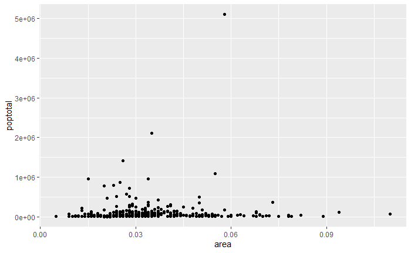

```r
ggplot(data = midwest) +
  geom_point(mapping = aes(x = area, y = poptotal))
```

2. Color your points based on the variable `state` (information on 5 different states is included in this dataset). Additionally, size your points based on the variable `popdensity`. Do any points stand out from the rest?

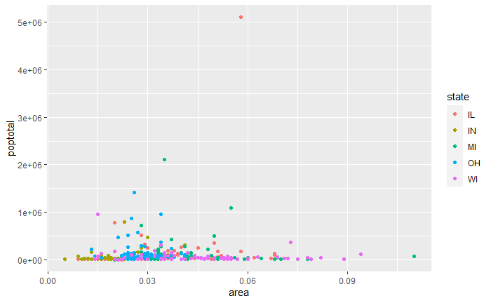

```r
ggplot(data = midwest) +
  geom_point(mapping = aes(x = area, y = poptotal, color = state))
```

3. Use the `labs()` layers to add a title and caption, and edit the x-label and y-label.

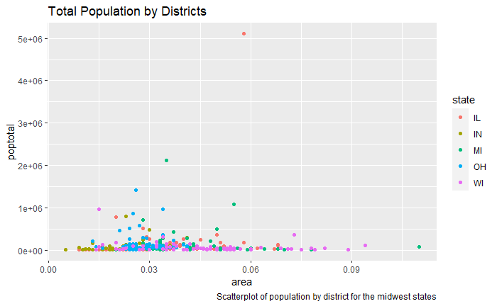

```r
ggplot(data = midwest) +
  geom_point(mapping = aes(x = area, y = poptotal, color = state)) +
  labs(title = "Total Population by Districts", xlabel = "District", ylabel = "Total Population", caption = "Scatterplot of population by district for the midwest states")
```

4. How would you limit the range of the variables `area` to the interval $[0, 0.1]$ and `poptotal` to $[0, 500000]$.? Comment on your results.

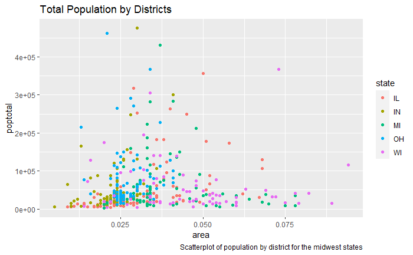

```r
ggplot(data = filter(midwest, area <= 0.1 & poptotal <= 500000)) +
  geom_point(mapping = aes(x = area, y = poptotal, color = state)) +
  labs(title = "Total Population by Districts", xlabel = "District", ylabel = "Total Population", caption = "Scatterplot of population by district for the midwest states")
```

When we apply the filter (which only requires the less than or equal to, as all values are positive numbers), we can see that this graph now has the points spread out more.

5. Create a plot to explore the answer to the question: *Is there a relationship between percent of population below the poverty level (`percbelowpoverty`) and the type of area (`inmetro`)?*

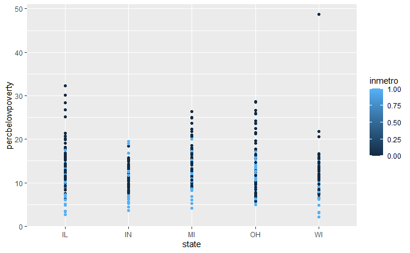

```r
ggplot(data = midwest) +
  geom_point(mapping = aes(x = state, y = percbelowpoverty, color = inmetro))
```

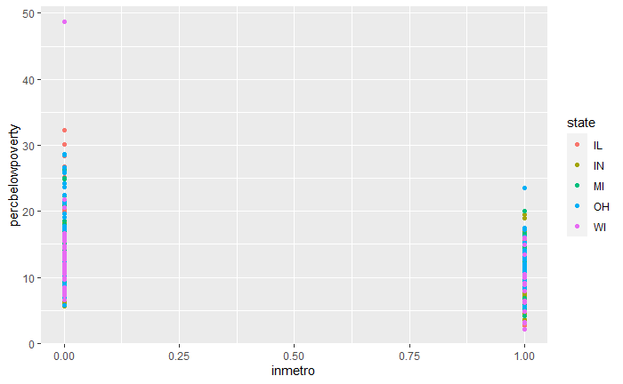

```r
ggplot(data = midwest) +
  geom_point(mapping = aes(x = inmetro, y = percbelowpoverty, color = state))
```

I made 2 graphs and added the states each are is from. In both, we can see that more often, areas outside of metro will be in poverty, but there isn’t much correlation.

# Problem 3

Load the `gapminder` package

```r
library(gapminder)
```

> if you have not installed this yet, make sure you install it, by typing `install.packages("gapminder")` in the `Console`, or using the `Install` button in the `Packages` tab in RStudio
1. Recreate the scatterplot (with the linear fit) shown in [Figure 3.13](https://socviz.co/makeplot.html#makeplot) of Kieran Healy’s Data Visualization book:

[figure not shown]

```r
str(gapminder)
```

```
tibble [1,704 x 6] (S3: tbl_df/tbl/data.frame)
 $ country  : Factor w/ 142 levels "Afghanistan",..: 1 1 1 1 1 1 1 1 1 1 ...
 $ continent: Factor w/ 5 levels "Africa","Americas",..: 3 3 3 3 3 3 3 3 3 3 ...
 $ year     : int [1:1704] 1952 1957 1962 1967 1972 1977 1982 1987 1992 1997 ...
 $ lifeExp  : num [1:1704] 28.8 30.3 32 34 36.1 ...
 $ pop      : int [1:1704] 8425333 9240934 10267083 11537966 13079460 14880372 12881816 13867957 16317921 22227415 ...
 $ gdpPercap: num [1:1704] 779 821 853 836 740 ...
```

```r
gapminder
```

| country | continent | year | lifeExp | pop | gdpPercap |
| --- | --- | --- | --- | --- | --- |
| Afghanistan | Asia | 1952 | 28.80100 | 8425333 | 779.4453 |
| Afghanistan | Asia | 1957 | 30.33200 | 9240934 | 820.8530 |
| Afghanistan | Asia | 1962 | 31.99700 | 10267083 | 853.1007 |
| Afghanistan | Asia | 1967 | 34.02000 | 11537966 | 836.1971 |
| Afghanistan | Asia | 1972 | 36.08800 | 13079460 | 739.9811 |
| Afghanistan | Asia | 1977 | 38.43800 | 14880372 | 786.1134 |
| Afghanistan | Asia | 1982 | 39.85400 | 12881816 | 978.0114 |
| Afghanistan | Asia | 1987 | 40.82200 | 13867957 | 852.3959 |
| Afghanistan | Asia | 1992 | 41.67400 | 16317921 | 649.3414 |
| Afghanistan | Asia | 1997 | 41.76300 | 22227415 | 635.3414 |

[output cut: 990 more lines]

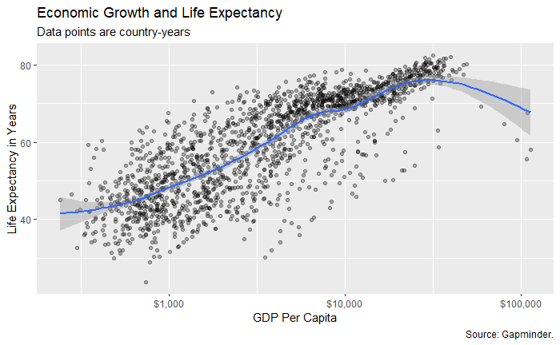

```r
p <- ggplot(data = gapminder, mapping = aes(x = gdpPercap, y=lifeExp))
p + geom_point(alpha = 0.3) +
    geom_smooth(method = "gam") +
    scale_x_log10(labels = scales::dollar) +
    labs(x = "GDP Per Capita", y = "Life Expectancy in Years",
         title = "Economic Growth and Life Expectancy",
         subtitle = "Data points are country-years",
         caption = "Source: Gapminder.")
```

This seems to be an expanded version of the graph that for some reason was cut off.

2. Is the figure above the best way to display this country-year data? What are we gaining and losing by ignoring the temporal and country-level structure of the data?

This is definitely not the best way to display the country-year data. Firstly, there is no colors to represent anything besides the line. By ignoring the temporal and country-level structure, you lose out on many details as well. However, you also gain some simplicity and a view of the overall data.

3. Pick 6 countries of your choice included in the `gapminder` dataset. Create a plot with life expectancy in years in the vertical axis, and GDP per capita in the horizontal axes. For each country include a regression line (`method = "lm"` in `geom_smooth()`). *Comment on your results.*

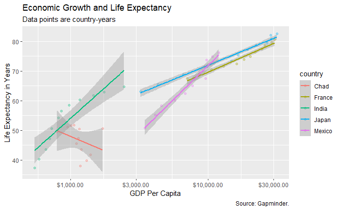

```r
d <- ggplot(data = filter(gapminder, country == "Japan" | country == "Russia" | country == "France" | country == "India" | country == "Mexico" | country == "Chad"), mapping = aes(x = gdpPercap, y=lifeExp, color = country))
d + geom_point(alpha = 0.3) +
    geom_smooth(method = "lm") +
    scale_x_log10(labels = scales::dollar) +
    labs(x = "GDP Per Capita", y = "Life Expectancy in Years",
         title = "Economic Growth and Life Expectancy",
         subtitle = "Data points are country-years",
         caption = "Source: Gapminder.")
```

# Problem 4

In this problem, you will use the `BostonHousing.csv` dataset available [here](https://github.com/reisanar/datasets/blob/master/BostonHousing.csv). It contains information concerning housing in the area of Boston, Massachusetts. The dataset includes information on 506 census housing tracts in the Boston area.

| Variables | Description |
| --- | --- |
| `CRIM` | Crime rate |
| `ZN` | Percentage of residential land zoned for lots over 25,000 ft2 |
| `INDUS` | Percentage of land occupied by non-retail business |
| `CHAS` | Does tract bound Charles River (`= 1` if tract bounds river, `= 0` otherwise) |
| `NOX` | Nitric oxide concentration (parts per 10 million) |
| `RM` | Average number of rooms per dwelling |
| `AGE` | Percentage of owner-occupied units built prior to 1940 |
| `DIS` | Weighted distances to five Boston employment centers |
| `RAD` | Index of accessibility to radial highways |
| `TAX` | Full-value property tax rate per $10,000 |
| `PTRATIO` | Pupil-to-teacher ratio by town |
| `LSTAT` | Percentage of lower status of the population |
| `MEDV` | Median value of owner-occupied homes in $1000s |
| `CAT_MEDV` | Is median value of owner-occupied homes in tract above $30,000 (`CAT.MEDV = 1`) or not (`CAT_MEDV = 0`) |

1. Read the dataset and produce *at least one* data summary of it (e.g. what is the variance and mean of every numerical attribute available?, what is the correlation between `PTRATIO` and `MEDV`?, etc.)

```r
# read the data
housing <- read_csv("https://raw.githubusercontent.com/reisanar/datasets/master/BostonHousing.csv")
```

```r
summary(housing)
```

```
      CRIM                ZN             INDUS            CHAS              NOX
 Min.   : 0.00632   Min.   :  0.00   Min.   : 0.46   Min.   :0.00000   Min.   :0.3850
 1st Qu.: 0.08205   1st Qu.:  0.00   1st Qu.: 5.19   1st Qu.:0.00000   1st Qu.:0.4490
 Median : 0.25651   Median :  0.00   Median : 9.69   Median :0.00000   Median :0.5380
 Mean   : 3.61352   Mean   : 11.36   Mean   :11.14   Mean   :0.06917   Mean   :0.5547
 3rd Qu.: 3.67708   3rd Qu.: 12.50   3rd Qu.:18.10   3rd Qu.:0.00000   3rd Qu.:0.6240
 Max.   :88.97620   Max.   :100.00   Max.   :27.74   Max.   :1.00000   Max.   :0.8710
       RM             AGE              DIS              RAD              TAX
 Min.   :3.561   Min.   :  2.90   Min.   : 1.130   Min.   : 1.000   Min.   :187.0
 1st Qu.:5.886   1st Qu.: 45.02   1st Qu.: 2.100   1st Qu.: 4.000   1st Qu.:279.0
 Median :6.208   Median : 77.50   Median : 3.207   Median : 5.000   Median :330.0
 Mean   :6.285   Mean   : 68.57   Mean   : 3.795   Mean   : 9.549   Mean   :408.2
 3rd Qu.:6.623   3rd Qu.: 94.08   3rd Qu.: 5.188   3rd Qu.:24.000   3rd Qu.:666.0
 Max.   :8.780   Max.   :100.00   Max.   :12.127   Max.   :24.000   Max.   :711.0
    PTRATIO          LSTAT            MEDV          CAT_MEDV
 Min.   :12.60   Min.   : 1.73   Min.   : 5.00   Min.   :0.000
 1st Qu.:17.40   1st Qu.: 6.95   1st Qu.:17.02   1st Qu.:0.000
 Median :19.05   Median :11.36   Median :21.20   Median :0.000
 Mean   :18.46   Mean   :12.65   Mean   :22.53   Mean   :0.166
 3rd Qu.:20.20   3rd Qu.:16.95   3rd Qu.:25.00   3rd Qu.:0.000
 Max.   :22.00   Max.   :37.97   Max.   :50.00   Max.   :1.000
```

```r
mean(housing$CRIM)
```

```
[1] 3.613524
```

2. Produce one data visualization to explore this dataset. Comment on your results.

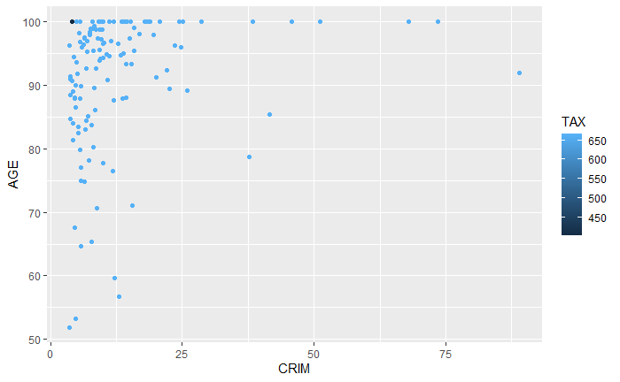

```r
ggplot(data = filter(housing, CRIM >= mean(housing$CRIM)), aes(x = CRIM, y = AGE, color=TAX)) +
  geom_point()
```

This is a graph that looks at the areas with above average crime rates, then compares the ages of the houses and the crime rates for those houses. You can also see the different Tax rates for each point. We can see that generally older houses will result in higher crime rates, and rarely will lower tax rates show for above average crime rate areas.